# Chicago Salaries

Madhav sai Avanigadda

2024-05-04

```r
# Installing and Switching on the required packages
library(tidyverse)
library(dplyr)
library(readr)
library(naniar)
```

```r
library(ggplot2)
library(epitools)
library(forcats)
library(stringr)
library(tibble)
library(lubridate)
library(skimr)
library(jhur)
library(broom)
library(faraway)
```

**1.Please describe what your data looks like and where you got it. Identify what the variables and samples are. Describe how the data was originally created.**

The dataset consists of information about current employees, their salaries, and position titles within various departments of an organization.

#### *Variables*

1. Job Titles: The title of the job held by the employee.
2. Department: The department where the employee works.
3. Full or Part-Time: Indicates whether the employee works full time (F) or part time (P).
4. Salary or Hourly: Specifies if the employee is paid a salary or on an hourly basis.
5. Typical Hours: The typical number of hours worked per week by hourly employees (non-null only for hourly workers).
6. Annual Salary: The annual salary for salaried employees (non-null only for salaried workers).
7. Hourly Rate: The hourly rate for hourly employees (non-null only for hourly workers).

#### *Data Description*

- The data set consists of 31,887 entries.
- There are non-null entries for all employees in the categories of job titles, department, full or part-time status, and salary or hourly status.
- Typical hours, annual salary, and hourly rate are populated based on whether an employee is hourly or salaried. For example, hourly employees have entries under “Typical Hours” and “Hourly Rate,” whereas salaried employees have entries under “Annual Salary.”

#### *Data Origin*

This data seems to be an official record from a public or large private organization, possibly tabeled for administrative, financial planning, or human resource management purposes. It reflects structured employment data that would typically be maintained in a payroll or human resources information system. This data is valuable for analysis related to employment patterns, salary distributions, and departmental staffing within the organization.

**2.Perform at least three different data sub-setting, cleaning, or manipulation methods that were described in this course on your data. Examples are: renaming the columns, recording values, reshaping the data, filtering the data, etc.**

```r
project <- read.csv("Project.csv")
project <- rename(project,Name_of_the_Job = Job.Titles)
project <- rownames_to_column(project,"Serial number")
head(project, n=5)
```

```
##   Serial number           Name_of_the_Job                           Department
## 1             1   CLERK - BD OF ELECTIONS      BOARD OF ELECTION COMMISSIONERS
## 2             2 SR PROCUREMENT SPECIALIST   DEPARTMENT OF PROCUREMENT SERVICES
## 3             3           ALDERMANIC AIDE                         CITY COUNCIL
## 4             4   POOL MOTOR TRUCK DRIVER DEPARTMENT OF STREETS AND SANITATION
## 5             5        SANITATION LABORER DEPARTMENT OF STREETS AND SANITATION
##   Full.or.Part.Time Salary.or.Hourly Typical.Hours Annual.Salary Hourly.Rate
## 1                 F           SALARY            NA         34176          NA
## 2                 F           SALARY            NA         90660          NA
## 3                 P           HOURLY            20            NA       36.80
## 4                 F           HOURLY            40            NA       45.98
## 5                 F           HOURLY            40            NA       40.76
```

```r
# I have created a column where total annual hourly salary is calculated by making an assumption individual will be working 50 weeks in an year
project$HourlySalary <- 50* project$Typical.Hours * project$Hourly.Rate
project$TotalSalary <- ifelse(is.na(project$Annual.Salary), project$HourlySalary, project$Annual.Salary)
head(project, n=10)
```

```
##    Serial number           Name_of_the_Job
## 1              1   CLERK - BD OF ELECTIONS
## 2              2 SR PROCUREMENT SPECIALIST
## 3              3           ALDERMANIC AIDE
## 4              4   POOL MOTOR TRUCK DRIVER
## 5              5        SANITATION LABORER
## 6              6          INQUIRY AIDE III
## 7              7           ALDERMANIC AIDE
## 8              8       PERSONNEL ASSISTANT
## 9              9    LEAVE OF ABSENCE ADMIN
## 10            10     FIREFIGHTER/PARAMEDIC
##                                Department Full.or.Part.Time Salary.or.Hourly
## 1         BOARD OF ELECTION COMMISSIONERS                 F           SALARY
## 2      DEPARTMENT OF PROCUREMENT SERVICES                 F           SALARY
## 3                            CITY COUNCIL                 P           HOURLY
```

[output cut: 18 more lines]

**3.Please describe what you did to clean/subset/wrangle/manipulate your data and why.** i have renamed a attribute in the dataset as it is better and convenient,added a column name as dataset don’t have one,then i have created a total salary column as i have many missing values in hourly rate Typicalhours and annual salary separately for my further usage i have created “Total salary” column

**4.Make two different kinds of visualizations of your data using ggplot2. Describe patterns that your visualizations demonstrate and the reasons for why you chose to explore those patterns.**

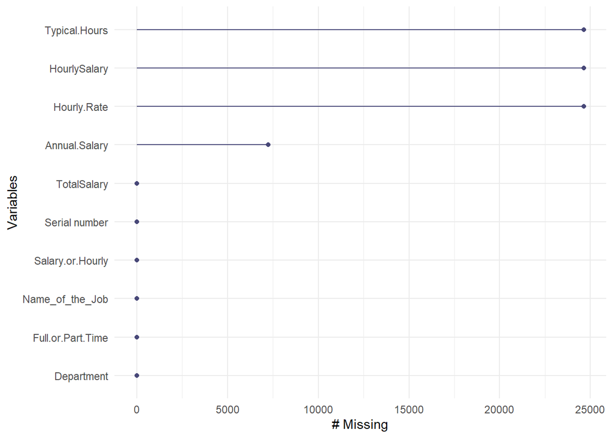

```r
gg_miss_var(project)
```

```r
### Plot to see how many missing values are present after i created new column "Total salary"
```